# Probability 1

## Royal Flush

A royal flush is \(A, K, Q, J, 10\) of the same suit.

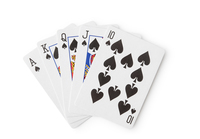

[figure not shown]

[figure not shown]

[figure not shown]

Every deck of cards contains \(4\) royal flushes.

## Calculation

- We have \(4\) possible royal flushes, we need to choose \(1\):

  \({4 \choose 1} = \dfrac{4}{1} = 4\)
- \({52 \choose 5}\) or \(2,598,960\) possible \(5\)-card hands
- …and \(4\) of them are royal flushes.
- Probability of getting a royal flush is \(\dfrac{4}{2,598,960}\).
  - or \(1\) in \(649,740\),
  - or \(0.000154\%\)

## What about 4 of a kind?

- Four cards with the same rank, e.g., \(2\heartsuit, 2\clubsuit, 2\diamondsuit, 2\spadesuit\)
- For a given rank, we need to pick *all four* of its cards: \(4 \choose 4\)
- There are \(13\) possible ranks, and our hand needs to contain four cards of that rank: \(13 \choose 1\)
- The fifth card must be of a different rank to all the others (one of the remaining \(12\) possible ranks): \(12 \choose 1\)…
- …and it should belong to one of the four possible suits: \(4 \choose 1\).

## What about 4 of a kind?

- Possible hands:

  \({13 \choose 1} \cdot {4 \choose 4} \cdot {12 \choose 1} \cdot {4 \choose 1}\)
  - \(= 13 \cdot 1 \cdot 12 \cdot 4 = 624\)

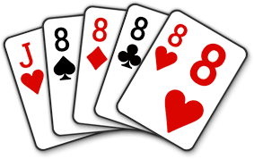

- \(624/2,598,960\),
- or \(1/4165\), or
- or \(0.024\%\).

## And now for something completely different

## Gameshow

Three doors: behind each one is a prize.

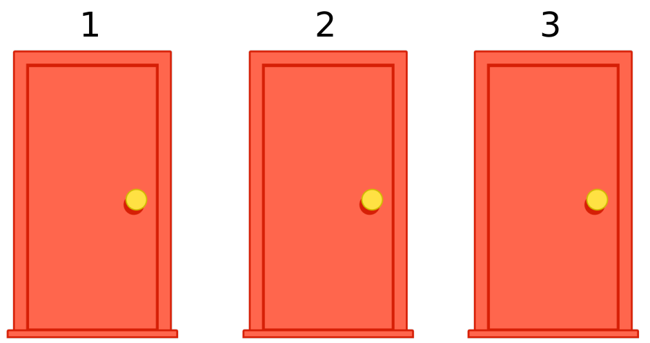

## Prizes

Behind \(2\) of the doors is a *goat*.

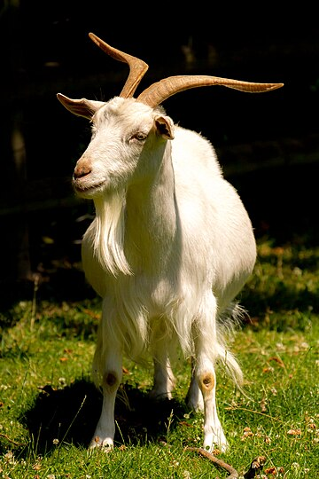

## Prizes

Behind \(1\) of the doors is a *sports car*.

[figure not shown]

## Round 1

The host asks you to pick a door. You choose door \(1\) at random.

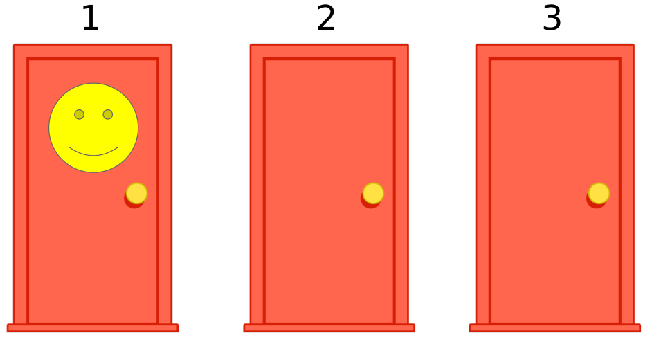

- \(2/3\) chance of choosing the goat,
- \(1/3\) chance of choosing the car.

## Round 2

The host opens one of the other doors to reveal a goat…

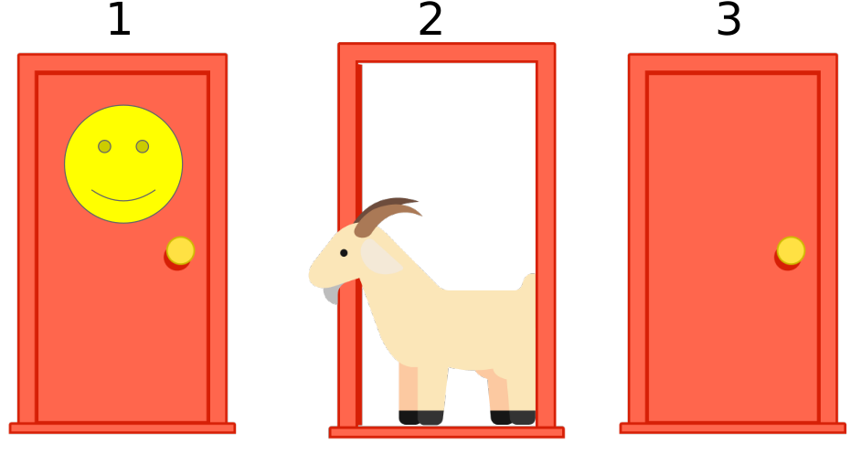

The host then asks whether you would like to stick with \(1\) or switch to \(3\). What do you do?

As a mathematician, you ask:

*“What is the probability that the car is behind door \(3\) now?”*

https://play.kahoot.it/v2/?quizId=9182a48d-4adb-4635-b57f-f1705a578c96&hostId=4998ab7f-5307-418c-8d99-b4fe762dc3d1

## The answer is…

- Door 1: \(1/3\)
- Door 3: \(2/3\)

## Explanation

- If *one* door conceils a goat and *one* door conceils a car, then surely the probability of choosing the car is \(1/2\), no matter which door you pick?
- No. Revealing the goat behind door \(2\) did not change the probability of door \(1\) conceiling the car.
- I.e., probability of the car being behind door \(1\) is *still* \(1/3\).

## What does this mean?

- The probability of the car being behind door \(1\) is *still* \(1/3\).
- The probability of the car being behind door \(2\) is \(0\).
- So the probability of the car being behind door \(3\) is \(1 - 1/3 = 2/3\).

## Let’s look at this another way…

| Chosen door | Car behind \(1\) | Car behind \(2\) | Car behind \(3\) |
| --- | --- | --- | --- |
| \(1\) | Stick | **Switch** | **Switch** |
| \(2\) | **Switch** | Stick | **Switch** |
| \(3\) | **Switch** | **Switch** | Stick |

You should switch \(2/3\) of the time.

[video not shown]

i

[https://youtu.be/9vRUxbzJZ9Y]

## Further reading

- Write some code to simulate the situation – repeat the process many times to model what happens if you stick or switch.
- Read up on the Monty Hall Problem

  https://en.wikipedia.org/wiki/Monty_Hall_problem

## Your final group challenge!

- Design either a board game or a wargame with cards and dice
- You can have as many of each as you like
- Design the game and then work out the probabilities of the dice rolls and card draws.
- Using probability, investigate how fair your game is.